# Linear Regression

Author

Dr Hazlienor Mohd Hatta

Published

April 15, 2024

# Background

## Problem statement

Diabetes Mellitus (DM) is a growing public health concern, with HbA1c (glycated hemoglobin) serving as a crucial marker for identifying individuals at risk and monitoring glycemic control. While DM diagnosis is important, focusing on HbA1c levels provides a more nuanced view of glycemic status across both diabetic and non-diabetic individuals. This study aims to explore the demographic, anthropometric, and clinical factors associated with HbA1c levels to better understand the risk and distribution of hyperglycemia in the general population.

## Objective

To identify key factors that are associated with variations in HbA1c levels among both diabetic and non-diabetic individuals.

## Assumption

- **Linearity:** The relationship between the independent variables and the dependent variable is assumed to be linear.
- **Normality of Residuals:** The residuals (differences between observed and predicted values) should be approximately normally distributed.
- **Homoscedasticity (Constant Variance of Residuals):** The residuals should have constant variance across all levels of the independent variables.
- **Independence of Observations:** Each observation should be independent of others; there should be no autocorrelation.
- **No Multicollinearity:** The independent variables should not be too highly correlated with each other.
- **No Influential Outliers:** The model should not be overly affected by extreme values or influential data points.

# Dataset description

| **Variable** | **Description** |
| --- | --- |
| `codesub` | Unique individual ID |
| `age` | Age in years |
| `dmdx` | Ever diagnosed with diabetes (0 = No, 1 = Yes) |
| `height` | Height in meters |
| `weight` | Weight in kg |
| `waist` | Waist circumference in cm |
| `hip` | Hip circumference in cm |
| `msbpr` | Mean systolic blood pressure (right arm, mmHg) |
| `mdbpr` | Mean diastolic blood pressure (right arm, mmHg) |
| `hba1c` | HbA1c level (mmol/l) |
| `fbs` | Fasting blood sugar (mmol/l) |
| `mogtt2h` | 2-hour post MOGTT glucose (mmol/l) |
| `totchol` | Total cholesterol (mmol/l) |
| `ftrigliz` | Fasting triglycerides (mmol/l) |
| `hdl` | HDL cholesterol (mmol/l) |
| `ldl` | LDL cholesterol (mmol/l) |
| `gender` | Gender (0 = Female, 1 = Male) |
| `crural` | Residence area (0 = Urban, 1 = Rural) |
| `bmi` | Body Mass Index (kg/m²) |

# Workflow

1. Prepare environment
2. Prepare data(read-view-transform-describe-explore)
3. Estimate: univariate analysis & Multivariate analysis - fitting the model (include interaction and confounding)
4. Inference
5. Prediction
6. Model assessment
7. Presentation

## Prepare environment

**Install required packages**

remove # when you run this code

```r
#install.packages(setdiff(c("haven", "psych", "tidyverse", "broom", "gtsummary", "ggplot2", "GGally", "lmtest", "rsq", "car", "sjPlot", "corrplot", "broom.helpers"), rownames(installed.packages())))
```

load library

```r
library(haven)       # To read SPSS, Stata, and SAS data files
library(psych)       # For descriptive statistics and psychometric analysis
library(tidyverse)   # for data manipulation and visualization
```

```
✖ ggplot2::%+%()   masks psych::%+%()
```

```r
library(broom)       # Converts model objects into tidy data frames
library(broom.helpers)
library(gtsummary)   # For publication-ready summary tables
library(ggplot2)     # Data visualization based on the grammar of graphics
library(GGally)      # for correlation plot, scatterplot matrices, etc.
library(lmtest)      # Diagnostic tests for linear regression
library(rsq)         # Calculates R-squared and adj R-squared
library(car)         # Companion to Applied Regression (tools like VIF, Anova)
library(sjPlot)      # Plotting and tabulating regression results
library(corrplot)    # plot correlation heatmap
```

## Load data

Lets rename the data as ‘diabetes’.

```r
diabetes <- read_dta("diabetes.dta")
summary(diabetes)
```

```
   codesub               age             dmdx            height
 Length:3820        Min.   :18.00   Min.   :0.0000   Min.   :1.290
 Class :character   1st Qu.:38.00   1st Qu.:0.0000   1st Qu.:1.510
 Mode  :character   Median :48.00   Median :0.0000   Median :1.560
                    Mean   :47.92   Mean   :0.1196   Mean   :1.568
                    3rd Qu.:58.00   3rd Qu.:0.0000   3rd Qu.:1.630
                    Max.   :89.00   Max.   :1.0000   Max.   :1.960

     weight           waist             hip             msbpr
 Min.   : 30.00   Min.   : 50.80   Min.   : 61.00   Min.   : 76.5
 1st Qu.: 53.60   1st Qu.: 77.00   1st Qu.: 91.00   1st Qu.:117.0
 Median : 62.00   Median : 86.00   Median : 97.00   Median :129.8
 Mean   : 63.25   Mean   : 85.92   Mean   : 97.51   Mean   :132.7
 3rd Qu.: 71.50   3rd Qu.: 94.40   3rd Qu.:104.00   3rd Qu.:146.0
 Max.   :128.50   Max.   :134.00   Max.   :148.00   Max.   :210.0
                  NA's   :2        NA's   :2
     mdbpr            hba1c             fbs            mogtt2h
 Min.   : 41.50   Min.   : 3.800   Min.   : 2.500   Min.   : 0.170
 1st Qu.: 70.00   1st Qu.: 5.100   1st Qu.: 4.460   1st Qu.: 5.210
 Median : 77.50   Median : 5.400   Median : 5.160   Median : 6.610
 Mean   : 77.98   Mean   : 5.782   Mean   : 5.612   Mean   : 7.206
 3rd Qu.: 85.12   3rd Qu.: 5.800   3rd Qu.: 5.960   3rd Qu.: 8.350
 Max.   :123.00   Max.   :15.000   Max.   :28.010   Max.   :29.830
                                   NA's   :3        NA's   :420
    totchol         ftrigliz          hdl             ldl
 Min.   : 2.13   Min.   :0.180   Min.   :0.120   Min.   :0.510
 1st Qu.: 4.96   1st Qu.:0.920   1st Qu.:1.110   1st Qu.:2.800
 Median : 5.70   Median :1.250   Median :1.330   Median :3.460
 Mean   : 5.77   Mean   :1.511   Mean   :1.355   Mean   :3.543
 3rd Qu.: 6.50   3rd Qu.:1.752   3rd Qu.:1.550   3rd Qu.:4.220
 Max.   :14.91   Max.   :7.990   Max.   :4.430   Max.   :9.420

     gender           crural            bmi
 Min.   :0.0000   Min.   :0.0000   Min.   : 9.241
 1st Qu.:0.0000   1st Qu.:0.0000   1st Qu.:22.176
 Median :0.0000   Median :0.0000   Median :25.283
 Mean   :0.3463   Mean   :0.4762   Mean   :25.688
 3rd Qu.:1.0000   3rd Qu.:1.0000   3rd Qu.:28.674
 Max.   :1.0000   Max.   :1.0000   Max.   :42.374
```

## Data Exploration and Wrangling

```r
str(diabetes)
```

```
tibble [3,820 × 19] (S3: tbl_df/tbl/data.frame)
 $ codesub : chr [1:3820] "R-S615112" "MAA615089" "M-M616372" "MFM615361" ...
  ..- attr(*, "label")= chr "individual unique identifier"
  ..- attr(*, "format.stata")= chr "%15s"
 $ age     : num [1:3820] 70 20 29 25 37 43 26 28 48 20 ...
  ..- attr(*, "label")= chr "reported age (years)"
  ..- attr(*, "format.stata")= chr "%3.0f"
 $ dmdx    : dbl+lbl [1:3820] 0, 0, 0, 0, 0, 0, 0, 0, 0, 0, 0, 0, 0, 0, 0, 0, 0, 0,...
   ..@ label       : chr "ever been diagnosed with diabetes mellitus?"
   ..@ format.stata: chr "%3.0f"
   ..@ labels      : Named num [1:2] 0 1
   .. ..- attr(*, "names")= chr [1:2] "no" "yes"
 $ height  : num [1:3820] 1.54 1.74 1.54 1.6 1.44 1.46 1.47 1.61 1.68 1.55 ...
  ..- attr(*, "label")= chr "height (meter)"
  ..- attr(*, "format.stata")= chr "%9.2f"
 $ weight  : num [1:3820] 40 54.6 37 48.4 44.5 45.5 48 40 48.4 41 ...
  ..- attr(*, "label")= chr "weight (kg)"
  ..- attr(*, "format.stata")= chr "%9.1f"
 $ waist   : num [1:3820] 76 83 83 83.5 85 90 91 80 82 79 ...
  ..- attr(*, "label")= chr "waist circum (cm)"
  ..- attr(*, "format.stata")= chr "%9.1f"
 $ hip     : num [1:3820] 61 62 63 64 64 64 64 64 65 66 ...
  ..- attr(*, "label")= chr "hip circum (cm)"
  ..- attr(*, "format.stata")= chr "%9.1f"
 $ msbpr   : num [1:3820] 135 105 91 117 102 124 120 85 112 108 ...
  ..- attr(*, "label")= chr "mean SBP for right arm (mmHG)"
  ..- attr(*, "format.stata")= chr "%9.2f"
 $ mdbpr   : num [1:3820] 80 58 60 68.5 78 65.5 77 60 74 52 ...
  ..- attr(*, "label")= chr "mean DBP for right arm (mmHG)"
  ..- attr(*, "format.stata")= chr "%9.2f"
 $ hba1c   : num [1:3820] 5.2 5.3 4.8 4.8 5.1 5.1 4.8 4.9 5.6 4.2 ...
  ..- attr(*, "label")= chr "mmol/l"
  ..- attr(*, "format.stata")= chr "%9.2f"
 $ fbs     : num [1:3820] 3.99 4.26 4.94 4.6 4.6 4.42 3.82 4.4 4.8 3.68 ...
  ..- attr(*, "label")= chr "fasting blood sugar (mmol/l)"
  ..- attr(*, "format.stata")= chr "%9.2f"
 $ mogtt2h : num [1:3820] 3.22 6.49 5.15 3.85 7.71 5.65 5.88 4.89 4.29 2.59 ...
  ..- attr(*, "label")= chr "MOGTT 2 hour post (mmol/l)"
  ..- attr(*, "format.stata")= chr "%9.2f"
 $ totchol : num [1:3820] 5.43 5.13 5.55 4.01 5.21 6.19 4.33 5.84 6.14 6.02 ...
```

[output cut: 9 more lines]

```
  ..- attr(*, "label")= chr "low-density lipoprotein (mmol/l)"
  ..- attr(*, "format.stata")= chr "%9.2f"
 $ gender  : dbl+lbl [1:3820] 0, 1, 0, 1, 0, 0, 0, 0, 1, 0, 0, 0, 0, 0, 0, 0, 0, 0,...
   ..@ label       : chr "gender"
   ..@ format.stata: chr "%9.0g"
   ..@ labels      : Named num [1:2] 0 1
   .. ..- attr(*, "names")= chr [1:2] "female" "male"
 $ crural  : dbl+lbl [1:3820] 1, 1, 1, 1, 1, 1, 1, 1, 1, 1, 1, 1, 0, 1, 0, 1, 1, 0,...
   ..@ label       : chr "rural=1 urban=0"
   ..@ format.stata: chr "%9.0g"
   ..@ labels      : Named num [1:2] 0 1
   .. ..- attr(*, "names")= chr [1:2] "urban" "rural"
 $ bmi     : num [1:3820] 16.9 18 15.6 18.9 21.5 ...
  ..- attr(*, "label")= chr "weight (kg)"
  ..- attr(*, "format.stata")= chr "%9.1f"
```

convert all categorical variable as factor

```r
diabetes <-
  diabetes %>%
  mutate(across(where(is.labelled), as_factor))
glimpse(diabetes)
```

```
Rows: 3,820
Columns: 19
$ codesub  <chr> "R-S615112", "MAA615089", "M-M616372", "MFM615361", "R-A61578…
$ age      <dbl> 70, 20, 29, 25, 37, 43, 26, 28, 48, 20, 56, 55, 26, 39, 18, 2…
$ dmdx     <fct> no, no, no, no, no, no, no, no, no, no, no, no, no, no, no, n…
$ height   <dbl> 1.54, 1.74, 1.54, 1.60, 1.44, 1.46, 1.47, 1.61, 1.68, 1.55, 1…
$ weight   <dbl> 40.0, 54.6, 37.0, 48.4, 44.5, 45.5, 48.0, 40.0, 48.4, 41.0, 5…
$ waist    <dbl> 76.0, 83.0, 83.0, 83.5, 85.0, 90.0, 91.0, 80.0, 82.0, 79.0, 9…
$ hip      <dbl> 61, 62, 63, 64, 64, 64, 64, 64, 65, 66, 67, 67, 67, 67, 67, 6…
$ msbpr    <dbl> 135.0, 105.0, 91.0, 117.0, 102.0, 124.0, 120.0, 85.0, 112.0, …
$ mdbpr    <dbl> 80.0, 58.0, 60.0, 68.5, 78.0, 65.5, 77.0, 60.0, 74.0, 52.0, 1…
$ hba1c    <dbl> 5.2, 5.3, 4.8, 4.8, 5.1, 5.1, 4.8, 4.9, 5.6, 4.2, 5.1, 5.3, 4…
$ fbs      <dbl> 3.99, 4.26, 4.94, 4.60, 4.60, 4.42, 3.82, 4.40, 4.80, 3.68, 6…
$ mogtt2h  <dbl> 3.22, 6.49, 5.15, 3.85, 7.71, 5.65, 5.88, 4.89, 4.29, 2.59, 7…
$ totchol  <dbl> 5.43, 5.13, 5.55, 4.01, 5.21, 6.19, 4.33, 5.84, 6.14, 6.02, 6…
$ ftrigliz <dbl> 1.06, 1.17, 0.72, 1.12, 0.78, 1.11, 0.73, 0.79, 1.63, 0.81, 1…
$ hdl      <dbl> 1.65, 1.59, 2.24, 1.21, 1.43, 2.18, 0.98, 1.81, 1.63, 1.47, 1…
$ ldl      <dbl> 2.69, 2.79, 2.55, 1.83, 2.40, 2.93, 1.82, 3.43, 3.71, 2.77, 3…
$ gender   <fct> female, male, female, male, female, female, female, female, m…
$ crural   <fct> rural, rural, rural, rural, rural, rural, rural, rural, rural…
$ bmi      <dbl> 16.86625, 18.03409, 15.60128, 18.90625, 21.46026, 21.34547, 2…
```

summary of all variables

```r
summary(diabetes)
```

```
   codesub               age         dmdx          height          weight
 Length:3820        Min.   :18.00   no :3363   Min.   :1.290   Min.   : 30.00
 Class :character   1st Qu.:38.00   yes: 457   1st Qu.:1.510   1st Qu.: 53.60
 Mode  :character   Median :48.00              Median :1.560   Median : 62.00
                    Mean   :47.92              Mean   :1.568   Mean   : 63.25
                    3rd Qu.:58.00              3rd Qu.:1.630   3rd Qu.: 71.50
                    Max.   :89.00              Max.   :1.960   Max.   :128.50

     waist             hip             msbpr           mdbpr
 Min.   : 50.80   Min.   : 61.00   Min.   : 76.5   Min.   : 41.50
 1st Qu.: 77.00   1st Qu.: 91.00   1st Qu.:117.0   1st Qu.: 70.00
 Median : 86.00   Median : 97.00   Median :129.8   Median : 77.50
 Mean   : 85.92   Mean   : 97.51   Mean   :132.7   Mean   : 77.98
 3rd Qu.: 94.40   3rd Qu.:104.00   3rd Qu.:146.0   3rd Qu.: 85.12
 Max.   :134.00   Max.   :148.00   Max.   :210.0   Max.   :123.00
 NA's   :2        NA's   :2
     hba1c             fbs            mogtt2h          totchol
 Min.   : 3.800   Min.   : 2.500   Min.   : 0.170   Min.   : 2.13
 1st Qu.: 5.100   1st Qu.: 4.460   1st Qu.: 5.210   1st Qu.: 4.96
 Median : 5.400   Median : 5.160   Median : 6.610   Median : 5.70
 Mean   : 5.782   Mean   : 5.612   Mean   : 7.206   Mean   : 5.77
 3rd Qu.: 5.800   3rd Qu.: 5.960   3rd Qu.: 8.350   3rd Qu.: 6.50
 Max.   :15.000   Max.   :28.010   Max.   :29.830   Max.   :14.91
                  NA's   :3        NA's   :420
    ftrigliz          hdl             ldl           gender       crural
 Min.   :0.180   Min.   :0.120   Min.   :0.510   female:2497   urban:2001
 1st Qu.:0.920   1st Qu.:1.110   1st Qu.:2.800   male  :1323   rural:1819
 Median :1.250   Median :1.330   Median :3.460
 Mean   :1.511   Mean   :1.355   Mean   :3.543
 3rd Qu.:1.752   3rd Qu.:1.550   3rd Qu.:4.220
 Max.   :7.990   Max.   :4.430   Max.   :9.420

      bmi
 Min.   : 9.241
 1st Qu.:22.176
 Median :25.283
 Mean   :25.688
 3rd Qu.:28.674
 Max.   :42.374
```

lets examine the distribution of some of the variables

you can use histogram

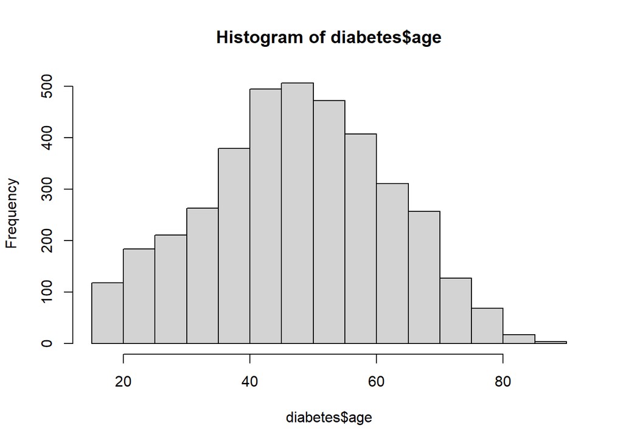

```r
hist(diabetes$age)
```

or boxplot

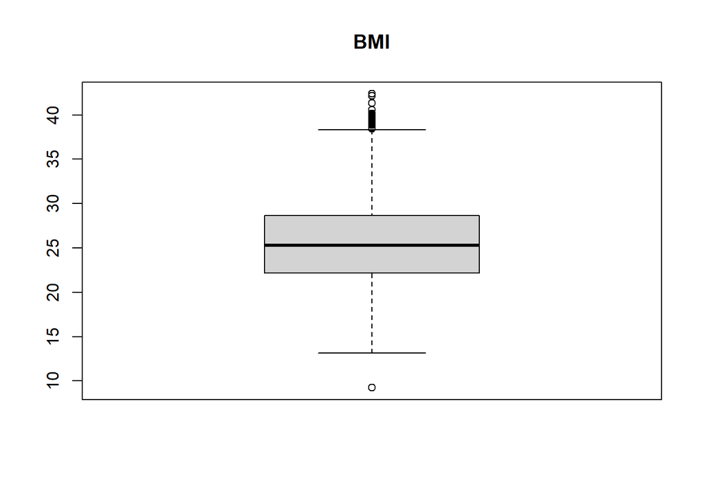

```r
boxplot(diabetes$bmi,
        main = "BMI")
```

Lets visualize the relationship between some of the independent variables and dependent variables

categorical independent variable vs outcome variable

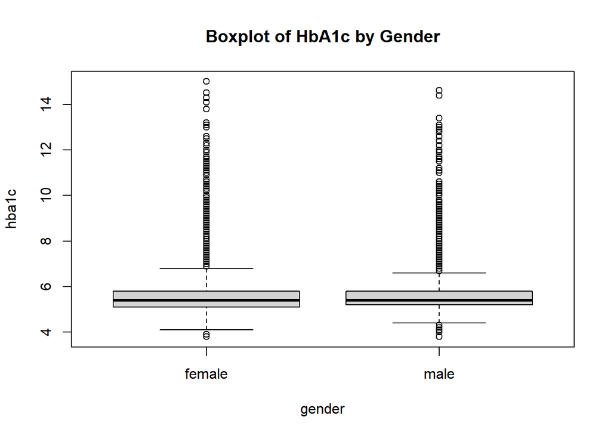

```r
boxplot(hba1c ~ gender,
        data = diabetes,
        main = "Boxplot of HbA1c by Gender")
```

between numerical variable

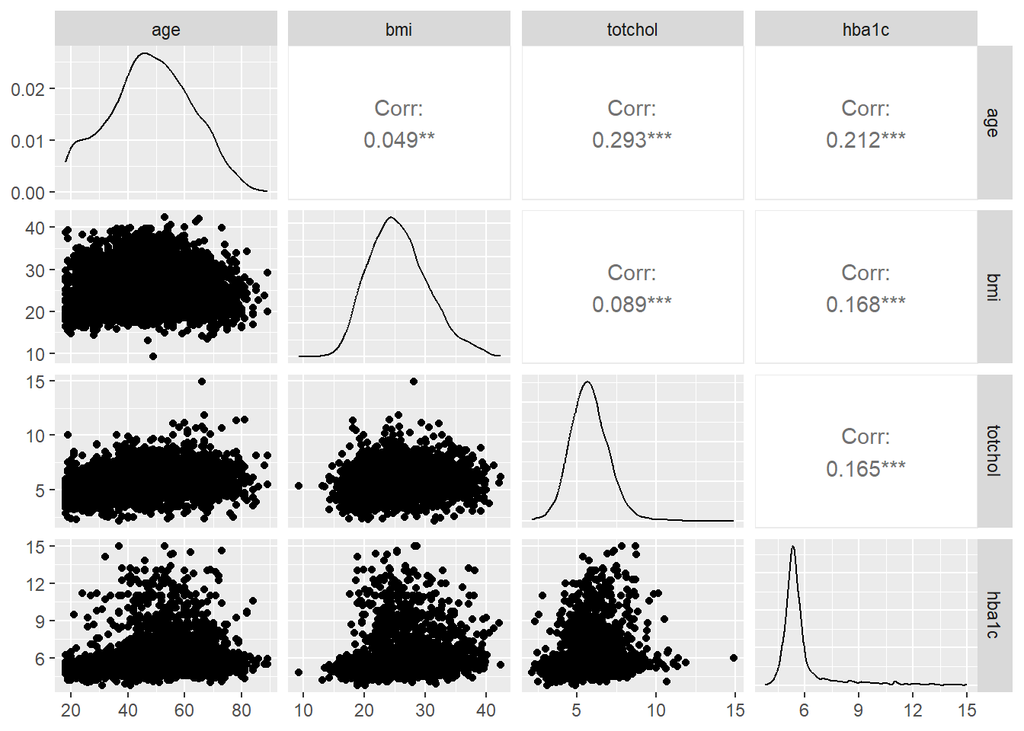

```r
ggpairs(diabetes, columns = c("age", "bmi", "totchol", "hba1c"))
```

or calculate the pairwise Pearson correlation coefficients

```r
corr <- diabetes %>% dplyr::select(age, msbpr, mdbpr, fbs, mogtt2h,
                    totchol, ftrigliz, hdl, hba1c) %>%
                    cor(use = 'complete.obs')
corr
```

```
               age         msbpr       mdbpr        fbs    mogtt2h   totchol
age      1.0000000  0.4620798206  0.23285555 0.19987906 0.23262123 0.3197574
msbpr    0.4620798  1.0000000000  0.70590712 0.18927229 0.24627112 0.2294469
mdbpr    0.2328556  0.7059071218  1.00000000 0.11591985 0.22761075 0.1699067
fbs      0.1998791  0.1892722892  0.11591985 1.00000000 0.58038766 0.1510847
mogtt2h  0.2326212  0.2462711155  0.22761075 0.58038766 1.00000000 0.1758102
totchol  0.3197574  0.2294468569  0.16990668 0.15108470 0.17581025 1.0000000
ftrigliz 0.1344983  0.1982708510  0.20160139 0.20117235 0.22259611 0.2622780
hdl      0.1550559 -0.0007760886 -0.06934124 0.02614275 0.02397262 0.2977744
hba1c    0.1803353  0.1696330617  0.15976357 0.47267932 0.54039620 0.1673330
           ftrigliz           hdl      hba1c
age       0.1344983  0.1550558640 0.18033534
msbpr     0.1982709 -0.0007760886 0.16963306
mdbpr     0.2016014 -0.0693412366 0.15976357
fbs       0.2011723  0.0261427482 0.47267932
mogtt2h   0.2225961  0.0239726230 0.54039620
totchol   0.2622780  0.2977743622 0.16733302
ftrigliz  1.0000000 -0.1965275908 0.18404143
hdl      -0.1965276  1.0000000000 0.01315491
hba1c     0.1840414  0.0131549124 1.00000000
```

or create a correlation heatmap

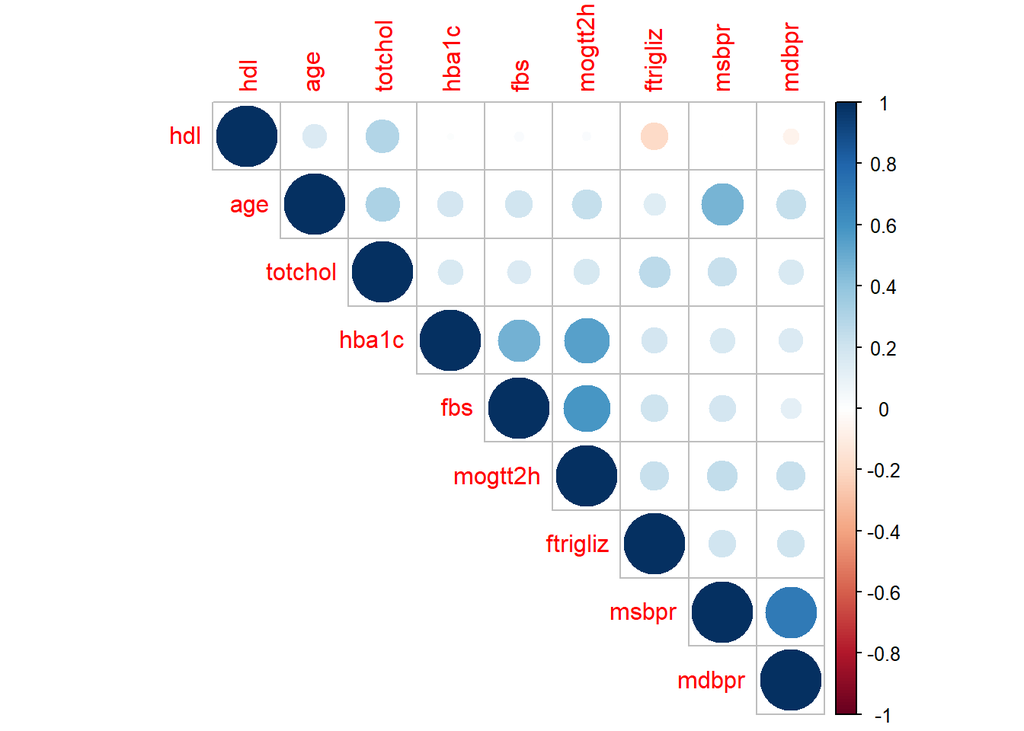

```r
corrplot(corr, type = 'upper', order = 'hclust')
```

## Estimate

### Univariable Analysis

Lets do univariable analysis first:

- **Identify variables** that have a significant association with the outcome when considered **individually**. This is useful before building a multivariable model.
- When the **effect size** changes between univariable and multivariable regression — either stronger or weaker — it gives insight into how the predictor interacts with other variables.
  - If a **confounder** is present, the effect size in simple linear regression is often larger and becomes smaller after adjustment in multiple linear regression.
  - Sometimes a variable that shows little or no association in SLR becomes important in MLR because another variable was masking its effect (**suppression**)
  - If two or more predictors are strongly correlated, the model may have difficulty estimating their individual effects accurately. This can cause large changes in the coefficients when moving from SLR to MLR (**multicollinearity**)

Lets build a SLR model with hba1c as outcome variable and **age, gender, crural, bmi, totchol** as independent variable.

Age first.

```r
uv_age <- lm(hba1c ~ age, data = diabetes)
summary(uv_age)
```

```
Call:
lm(formula = hba1c ~ age, data = diabetes)

Residuals:
    Min      1Q  Median      3Q     Max
-2.2073 -0.6228 -0.3218  0.0157  9.4387

Coefficients:
            Estimate Std. Error t value Pr(>|t|)
(Intercept) 4.814317   0.075467   63.79   <2e-16 ***
age         0.020188   0.001508   13.39   <2e-16 ***
---
Signif. codes:  0 '***' 0.001 '**' 0.01 '*' 0.05 '.' 0.1 ' ' 1

Residual standard error: 1.348 on 3818 degrees of freedom
Multiple R-squared:  0.04485,   Adjusted R-squared:  0.0446
F-statistic: 179.3 on 1 and 3818 DF,  p-value: < 2.2e-16
```

Lets understand the output

- **Intercept**: When age = 0, the predicted HbA1c is **4.814** (age is never 0 but provide the baseline value).
- **age**: For every one-year increase in age, HbA1c increases by **0.0202 units**, on average.
- **Std. Error**: Standard error for the estimate; smaller values indicate more precision.
- **t value**: Tests whether the coefficient differs from 0. A high value means it’s unlikely due to chance.
- **Pr(>|t|)**: p-value; <0.05 means it’s statistically **significant**.
- **F-statistic**: 179.3, p <0.05, → Overall model is statistically significant.
- **R-squared**: 0.04485, → Only **4.5%** of the variation in HbA1c is explained by age.
- **Adjusted R-squared = 0.0446** is very close to the R-squared, suggesting that the inclusion of the predictor (age) doesn’t drastically increase the explanatory power when accounting for the number of predictors.
- **Degrees of freedom**: 3818 (n - number of predictors - 1)

Lets do for another independent variable

```r
uv_bmi <- lm(hba1c ~ bmi, data = diabetes)
summary(uv_bmi)
```

```
Call:
lm(formula = hba1c ~ bmi, data = diabetes)

Residuals:
    Min      1Q  Median      3Q     Max
-2.1768 -0.6215 -0.3374  0.0146  9.0918

Coefficients:
            Estimate Std. Error t value Pr(>|t|)
(Intercept) 4.546651   0.119232   38.13   <2e-16 ***
bmi         0.048078   0.004562   10.54   <2e-16 ***
---
Signif. codes:  0 '***' 0.001 '**' 0.01 '*' 0.05 '.' 0.1 ' ' 1

Residual standard error: 1.36 on 3818 degrees of freedom
Multiple R-squared:  0.02827,   Adjusted R-squared:  0.02802
F-statistic: 111.1 on 1 and 3818 DF,  p-value: < 2.2e-16
```

You can do the univariable analysis for each independent variables one by one.

Or, you can use **tbl_uvregression** from **gtsummary** package

```r
slr_model <- tbl_uvregression(
    diabetes,
    method = lm,
    y = hba1c,
    include = c("age", "gender", "crural", "bmi", "totchol")
  )
slr_model
```

| **Characteristic** | **N** | **Beta** | **95% CI** | **p-value** |
| --- | --- | --- | --- | --- |
| reported age (years) | 3,820 | 0.02 | 0.02, 0.02 | <0.001 |
| gender | 3,820 |  |  |  |
| female |  | — | — |  |
| male |  | 0.07 | -0.02, 0.16 | 0.13 |
| rural=1 urban=0 | 3,820 |  |  |  |
| urban |  | — | — |  |
| rural |  | 0.11 | 0.02, 0.20 | 0.015 |
| weight (kg) | 3,820 | 0.05 | 0.04, 0.06 | <0.001 |
| total cholesterol (mmol/l) | 3,820 | 0.19 | 0.15, 0.22 | <0.001 |

Abbreviation: CI = Confidence Interval

### Multivariable analysis

select the variables to be included in the multivariable model:

- Priori knowledge, literature review, Directed Acyclic Graph (DAG)
- Clinical significance
- Statistical significance
- Automatic selection - backward/forward
- Avoid Collinearity - Highly correlated predictors should not both be included

Lets build a model with these risk factors: **age, gender, crural, bmi, totchol**

```r
mlr1 <- lm(hba1c ~ age + gender + crural + bmi + totchol, data = diabetes)
summary(mlr1)
```

```
Call:
lm(formula = hba1c ~ age + gender + crural + bmi + totchol, data = diabetes)

Residuals:
    Min      1Q  Median      3Q     Max
-2.4817 -0.6221 -0.3110  0.0657  8.9508

Coefficients:
            Estimate Std. Error t value Pr(>|t|)
(Intercept) 3.151502   0.155904  20.214  < 2e-16 ***
age         0.016524   0.001550  10.659  < 2e-16 ***
gendermale  0.088723   0.045239   1.961   0.0499 *
cruralrural 0.072730   0.043154   1.685   0.0920 .
bmi         0.044159   0.004481   9.855  < 2e-16 ***
totchol     0.110689   0.018631   5.941 3.08e-09 ***
---
Signif. codes:  0 '***' 0.001 '**' 0.01 '*' 0.05 '.' 0.1 ' ' 1

Residual standard error: 1.323 on 3814 degrees of freedom
Multiple R-squared:  0.08048,   Adjusted R-squared:  0.07927
F-statistic: 66.76 on 5 and 3814 DF,  p-value: < 2.2e-16
```

About **8.05%** of the variance in **HbA1c** is explained by the predictor variables in the model.

You can summarize the output in a table

```r
mlr1_t <-tbl_regression(mlr1)
mlr1_t
```

| **Characteristic** | **Beta** | **95% CI** | **p-value** |
| --- | --- | --- | --- |
| reported age (years) | 0.02 | 0.01, 0.02 | <0.001 |
| gender |  |  |  |
| female | — | — |  |
| male | 0.09 | 0.00, 0.18 | 0.050 |
| rural=1 urban=0 |  |  |  |
| urban | — | — |  |
| rural | 0.07 | -0.01, 0.16 | 0.092 |
| weight (kg) | 0.04 | 0.04, 0.05 | <0.001 |
| total cholesterol (mmol/l) | 0.11 | 0.07, 0.15 | <0.001 |

Abbreviation: CI = Confidence Interval

Lets compare with the previous SLR model

```r
tbl_merge(
  list(slr_model, mlr1_t),  # List of gtsummary models to merge
  tab_spanner = c("SLR", "MLR")  # Column headers for univariable and multivariable models
)
```

| **Characteristic** | SLR **N** | SLR **Beta** | SLR **95% CI** | SLR **p-value** | MLR **Beta** | MLR **95% CI** | MLR **p-value** |
| --- | --- | --- | --- | --- | --- | --- | --- |
| reported age (years) | 3,820 | 0.02 | 0.02, 0.02 | <0.001 | 0.02 | 0.01, 0.02 | <0.001 |
| gender | 3,820 |  |  |  |  |  |  |
| female |  | — | — |  | — | — |  |
| male |  | 0.07 | -0.02, 0.16 | 0.13 | 0.09 | 0.00, 0.18 | 0.050 |
| rural=1 urban=0 | 3,820 |  |  |  |  |  |  |
| urban |  | — | — |  | — | — |  |
| rural |  | 0.11 | 0.02, 0.20 | 0.015 | 0.07 | -0.01, 0.16 | 0.092 |
| weight (kg) | 3,820 | 0.05 | 0.04, 0.06 | <0.001 | 0.04 | 0.04, 0.05 | <0.001 |
| total cholesterol (mmol/l) | 3,820 | 0.19 | 0.15, 0.22 | <0.001 | 0.11 | 0.07, 0.15 | <0.001 |

Abbreviation: CI = Confidence Interval

lets **interpret** the result:

- After adjusting for gender, rural/urban status, BMI, and total cholesterol, age is positively associated with HbA1c. For each year increase in age, HbA1c increases by 0.02g/dl (95% CI: 0.01, 0.02, p < 0.001).
- After adjusting for age, gender, rural/urban status, and total cholesterol, each unit increase in BMI is associated with a 0.04g/dlincrease in HbA1c (95% CI: 0.04, 0.05, p < 0.001).
- After adjusting for age, gender, rural/urban status, and BMI, each unit (mmol/l) increase in total cholesterol is associated with a 0.11g/dl increase in HbA1c (95% CI: 0.07, 0.15, p < 0.001).
- In SLR, being from a rural area was significantly associated with a 0.11 increase in HbA1c compared to urban areas (95% CI: 0.02, 0.20, p = 0.015). However, in MLR, after adjusting for age, gender, BMI, and total cholesterol, the association weakens and becomes non-significant (Beta = 0.07, 95% CI: -0.01, 0.16, p = 0.092).
  - In the SLR model, the relationship between rural/urban and HbA1c might have been influenced by confounding variables such as **age, BMI, gender, or cholesterol levels**. When these variables are included in the MLR model, they may explain some of the variance that was previously attributed to the rural/urban factor.
- In SLR, gender was not significantly associated with HbA1c (p = 0.13 for males compared to females). However, after adjusting for age, rural/urban status, BMI, and total cholesterol in MLR, being male is associated with a 0.09g/dl increase in HbA1c (95% CI: 0.00, 0.18, p = 0.050).
  - Gender could interact with other variables, such as BMI or age, which might have been masked in the SLR. In the MLR model, where these other variables are included, the effect of gender could become more apparent.

Lets check for **interaction** terms

You should examine the interaction between all numerical and numerical, categorical and categorical, and numerical and categorical variables.

~ Between gender and bmi

```r
mlr2 <- lm(hba1c ~ age + gender + crural + bmi + totchol + gender:bmi, data = diabetes)
summary(mlr2)
```

```
Call:
lm(formula = hba1c ~ age + gender + crural + bmi + totchol +
    gender:bmi, data = diabetes)

Residuals:
    Min      1Q  Median      3Q     Max
-2.4818 -0.6220 -0.3114  0.0655  8.9509

Coefficients:
                Estimate Std. Error t value Pr(>|t|)
(Intercept)    3.1531215  0.1730520  18.221  < 2e-16 ***
age            0.0165245  0.0015506  10.657  < 2e-16 ***
gendermale     0.0833513  0.2530047   0.329   0.7418
cruralrural    0.0727822  0.0432266   1.684   0.0923 .
bmi            0.0440969  0.0053167   8.294  < 2e-16 ***
totchol        0.1106789  0.0186392   5.938 3.14e-09 ***
gendermale:bmi 0.0002118  0.0098144   0.022   0.9828
---
Signif. codes:  0 '***' 0.001 '**' 0.01 '*' 0.05 '.' 0.1 ' ' 1

Residual standard error: 1.324 on 3813 degrees of freedom
Multiple R-squared:  0.08048,   Adjusted R-squared:  0.07903
F-statistic: 55.62 on 6 and 3813 DF,  p-value: < 2.2e-16
```

The interaction term is not significant.

### Model comparison

Lets compare the model

```r
anova(mlr1, mlr2)
```

```
Analysis of Variance Table

Model 1: hba1c ~ age + gender + crural + bmi + totchol
Model 2: hba1c ~ age + gender + crural + bmi + totchol + gender:bmi
  Res.Df    RSS Df  Sum of Sq     F Pr(>F)
1   3814 6679.3
2   3813 6679.3  1 0.00081573 5e-04 0.9828
```

For both models, the Residual Sum of Square (RSS) value is essentially the same (6679.3), indicating that the inclusion of the interaction term does not reduce the residual variance.

The F-statistic is 5e-04, which is very close to 0, indicating no substantial improvement in the model by adding the interaction term.

The p-value for the F-test is > 0.05. This suggests that the addition of the interaction term **does not significantly improve** the model. Model 1 (without the interaction term) is sufficient to explain the relationship between the predictors and **HbA1c**.

**Final model**

[figure not shown]

## Inference

Lets obtain the 95% Confidence Interval for our model estimate

```r
tidy(mlr1, conf.int = T)
```

```
# A tibble: 6 × 7
  term        estimate std.error statistic  p.value   conf.low conf.high
  <chr>          <dbl>     <dbl>     <dbl>    <dbl>      <dbl>     <dbl>
1 (Intercept)   3.15     0.156       20.2  2.12e-86  2.85         3.46
2 age           0.0165   0.00155     10.7  3.70e-26  0.0135       0.0196
3 gendermale    0.0887   0.0452       1.96 4.99e- 2  0.0000279    0.177
4 cruralrural   0.0727   0.0432       1.69 9.20e- 2 -0.0119       0.157
5 bmi           0.0442   0.00448      9.85 1.21e-22  0.0354       0.0529
6 totchol       0.111    0.0186       5.94 3.08e- 9  0.0742       0.147
```

## Prediction

Lets obtain the **fitted values** for **hba1c** in the regression model. The fitted values are the predicted values of the dependent variable based on the values of the independent variables (covariates), according to the model you fit.

```r
augment(mlr1)
```

```
# A tibble: 3,820 × 12
   hba1c   age gender crural   bmi totchol .fitted  .resid     .hat .sigma
   <dbl> <dbl> <fct>  <fct>  <dbl>   <dbl>   <dbl>   <dbl>    <dbl>  <dbl>
 1   5.2    70 female rural   16.9    5.43    5.73 -0.527  0.00244    1.32
 2   5.3    20 male   rural   18.0    5.13    5.01  0.292  0.00257    1.32
 3   4.8    29 female rural   15.6    5.55    5.01 -0.207  0.00229    1.32
 4   4.8    25 male   rural   18.9    4.01    5.00 -0.205  0.00241    1.32
 5   5.1    37 female rural   21.5    5.21    5.36 -0.260  0.00107    1.32
 6   5.1    43 female rural   21.3    6.19    5.56 -0.463  0.000998   1.32
 7   4.8    26 female rural   22.2    4.33    5.11 -0.314  0.00162    1.32
 8   4.9    28 female rural   15.4    5.84    5.01 -0.115  0.00243    1.32
 9   5.6    48 male   rural   17.1    6.14    5.54  0.0570 0.00176    1.32
10   4.2    20 female rural   17.1    6.02    4.97 -0.775  0.00265    1.32
# ℹ 3,810 more rows
# ℹ 2 more variables: .cooksd <dbl>, .std.resid <dbl>
```

**Predict new data**

lets predict the **HbA1c** for a 70 year old male with BMI 38 and total cholesterol of 6 mmol/l living in urban area

```r
new.data <- expand.grid(age = 70,
                         bmi = 38,
                         totchol = 6,
                         gender = 'male',
                         crural = 'urban')

augment(mlr1,
        newdata = new.data)
```

```
# A tibble: 1 × 6
    age   bmi totchol gender crural .fitted
  <dbl> <dbl>   <dbl> <fct>  <fct>    <dbl>
1    70    38       6 male   urban     6.74
```

## Model checking

**Test Used**: Breusch-Pagan test (via `ncvTest`) to check for **non-constant variance** of residuals (a violation of linear regression assumptions).

**Null hypothesis (H₀)**: Constant variance of the residuals (homoscedasticity)

```r
ncvTest(mlr1)
```

```
Non-constant Variance Score Test
Variance formula: ~ fitted.values
Chisquare = 309.9433, Df = 1, p = < 2.22e-16
```

Since the **p-value is highly significant**, we **reject the null hypothesis** of constant variance. This means the **residuals do not have constant variance** — **heteroscedasticity is present**.

**Test used**: Studentized Breusch-Pagan test for heteroscedasticity

```r
bptest(mlr1)
```

```
    studentized Breusch-Pagan test

data:  mlr1
BP = 60.446, df = 5, p-value = 9.83e-12
```

Since the **p-value is highly significant**, we **reject the null hypothesis** of constant variance. This means the **residuals do not have constant variance** — **heteroscedasticity is present**.

**Test used**: Shapiro-Wilk test for normality for residuals

```r
shapiro.test(mlr1$residuals)
```

```
    Shapiro-Wilk normality test

data:  mlr1$residuals
W = 0.6512, p-value < 2.2e-16
```

Since the **p-value is <0.05**, you **reject the null hypothesis** of normality. This suggests a **violation of the normality assumption** for residuals.

you can also visualize it:

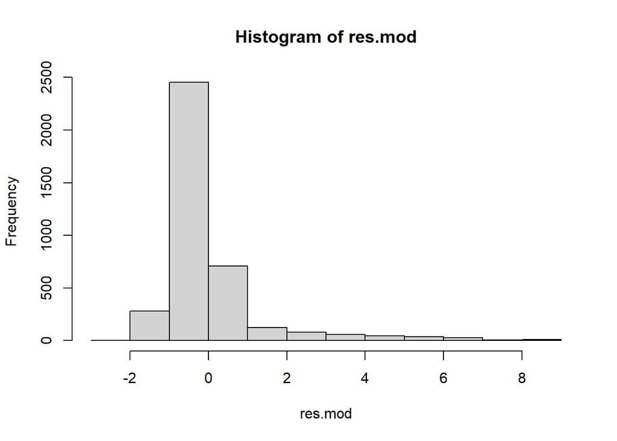

```r
res.mod <- residuals(mlr1)
hist(res.mod)
```

lets do the diagnostic plot

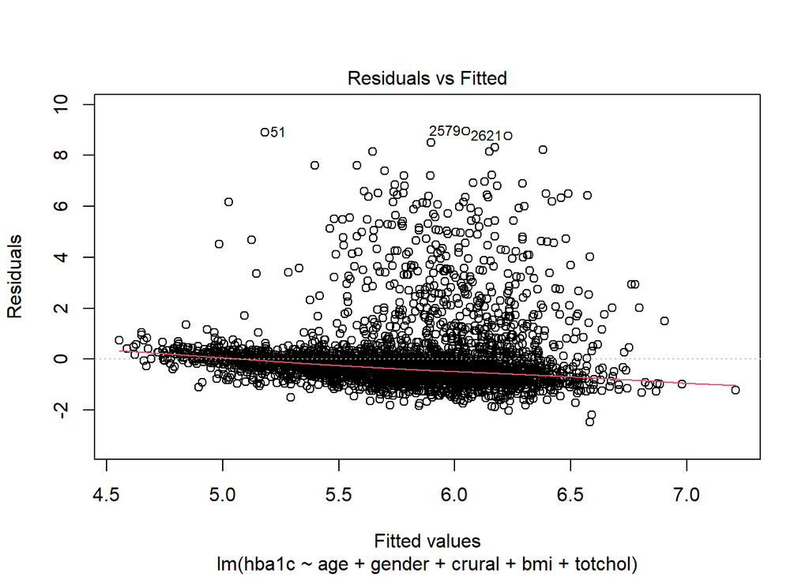

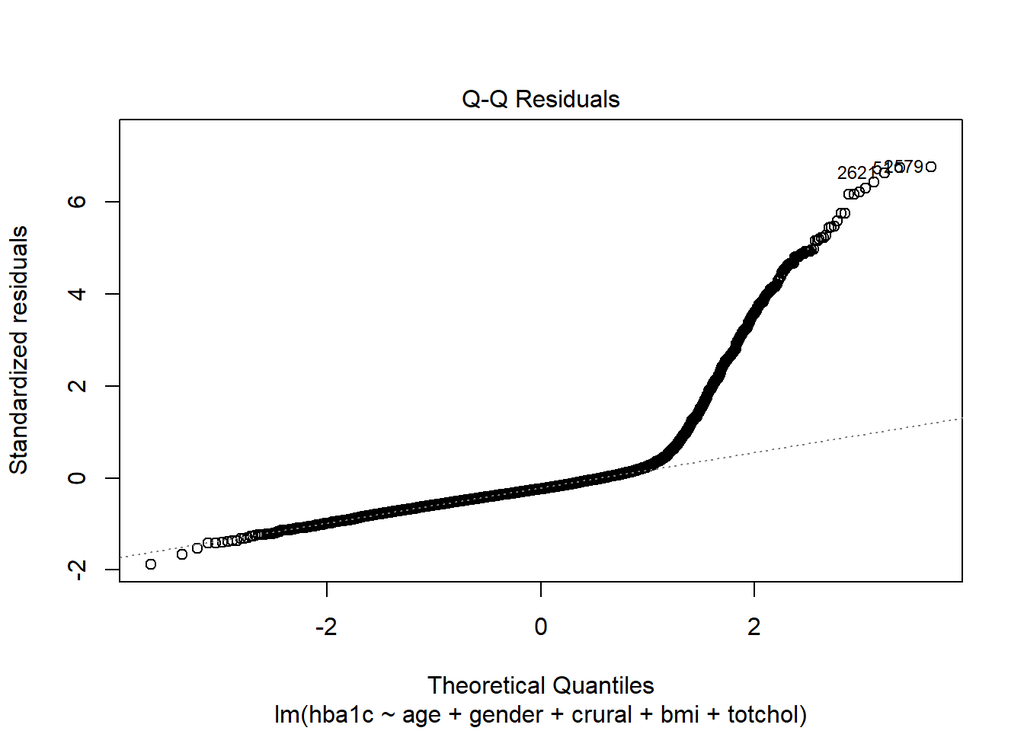

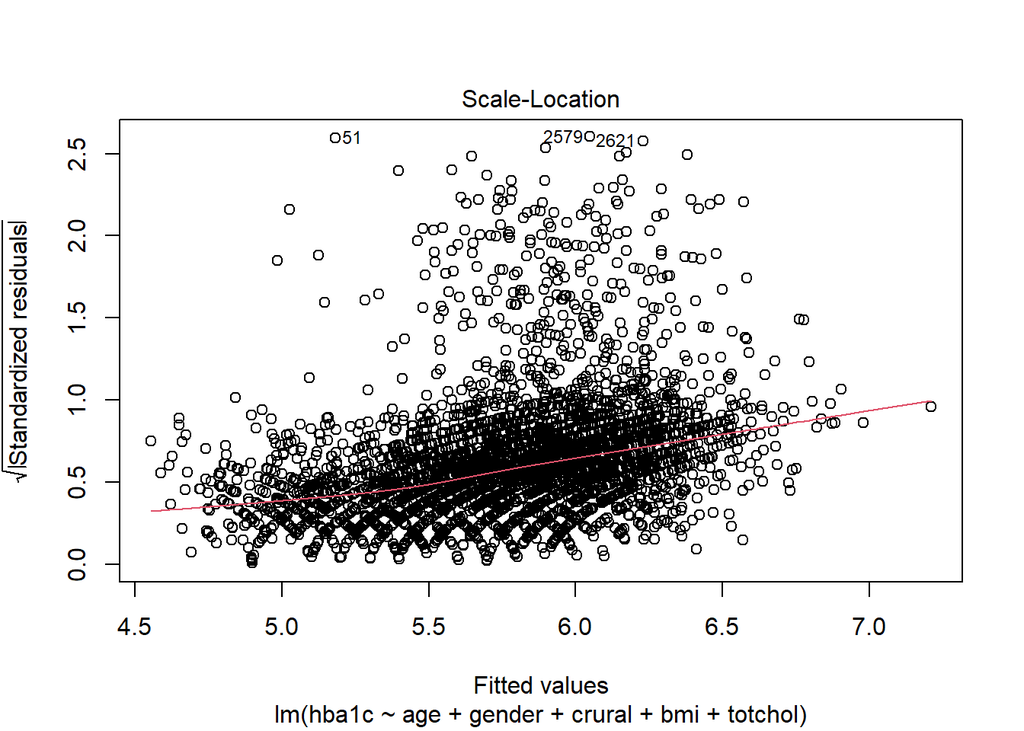

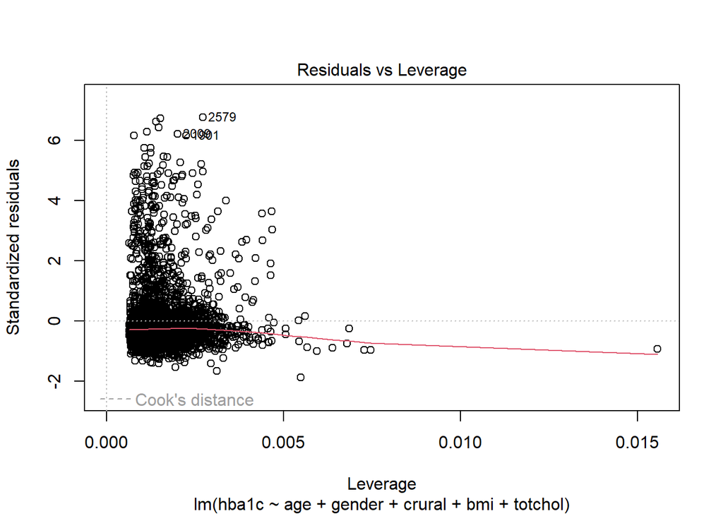

```r
plot(mlr1)
```

you can also use the **sjplot** package

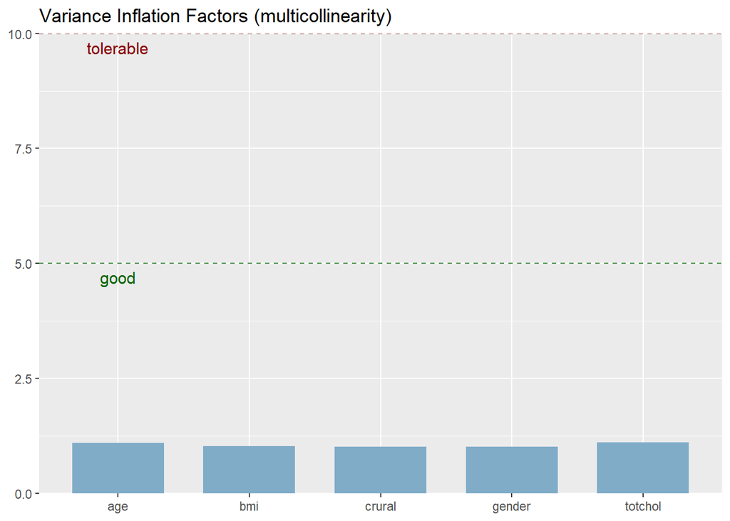

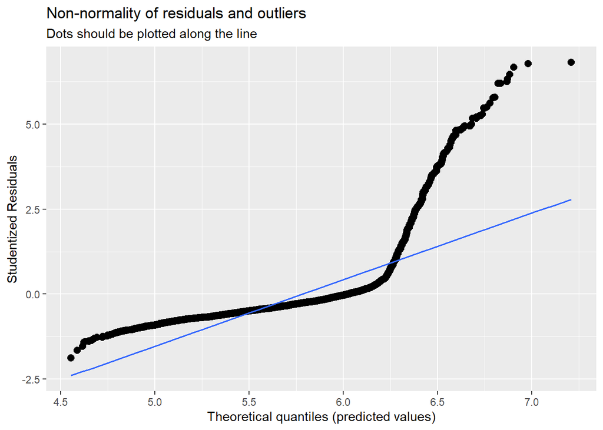

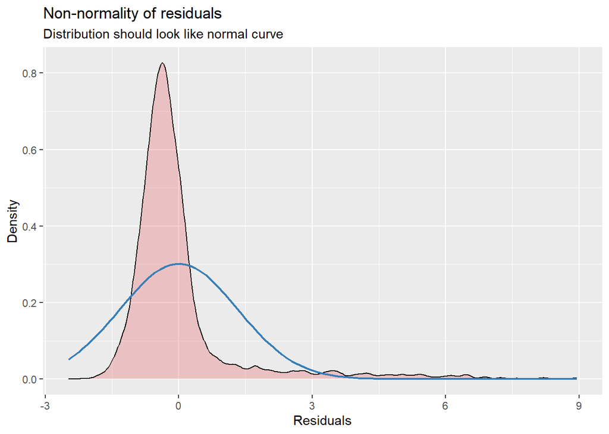

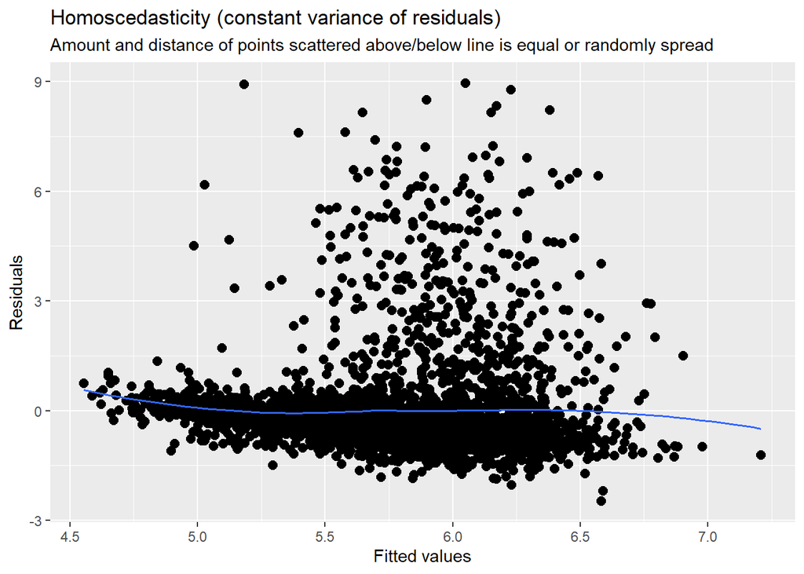

```r
plot_model(mlr1, type = "diag")
```

Also, check the extreme influential

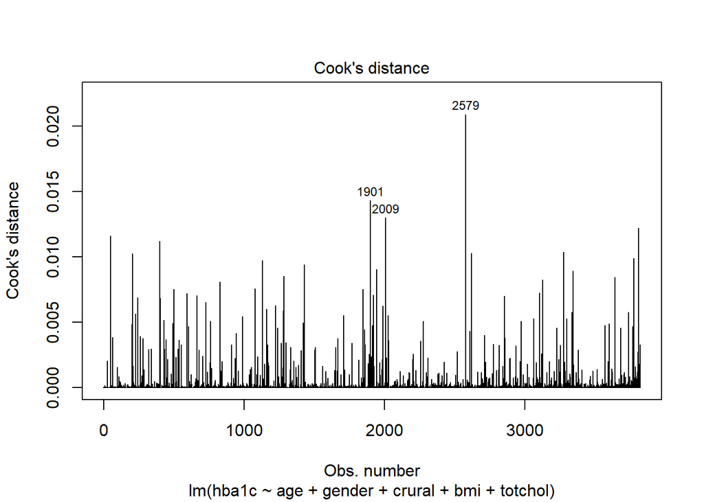

```r
plot(mlr1, which = 4)
```

what to do if assumptions violated?

- Transform the outcome variable - Try log or square root transformation
- Keeps your current model but adjusts standard errors to fix inference issues due to heteroscedasticity.
- Use robust regression methods that are less sensitive to violations of assumptions, such as GLM

**References**

https://stats.oarc.ucla.edu/r/dae/linear-regression-r-data-analysis-examples/

Kamarul Imran, Wan Nor Arifin, & Tengku Muhammad Hanis Tengku Mokhtar. (2024). *Data Analysis in Medicine and Health using R*. Retrieved from https://bookdown.org/drki_musa/dataanalysis/

Lilja, D. R. (2016). *Linear regression using R: An introduction to data modeling*. University of Minnesota Libraries Publishing.